# Introducción a SQL

[figure not shown]

**Luis Fernando Apáez Álvarez**  
26 de mayo del 2023

# SQL (Structured Query Language)

- Lenguaje de consultas estructuradas.
- Consulta: Proceso en el cual estraemos información de interés de una base de datos (BD).
- BD: recopilación organizada de datos estructurados. Intuitivamente, una BD es un compendio de tablas relacionadas entre sí.

[figure not shown]

# BD relacionales

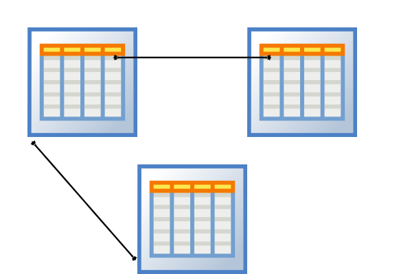

- Básicamente son tablas relacionadas entre sí.
- Por ejemplo: Si tenemos una BD de una tienda, podríamos tener tres tablas las cuales claramente estarán relacionadas:
  - Ventas.
  - Inventario.
  - Clientes.
- Para trabajar con BD relacionales podemos utilizar el lenguaje de programación SQL.

# SQL

Con el lenguaje SQL podemos:

- Crear bases de datos y tablas.
- Insertar, eliminar y actualizar información en nuestras tablas.
- Crear rutina, trabajar con funciones.
- Realizar consultas, es decir, estraer información de interés. Por ejemplo:
  - Obtener las ventas totales en cierto mes.
  - Detectar el producto que más se vende.

[figure not shown]

# SQL en Python

Podemos programar en SQL utilizando como intermediario a Python, para ello tenemos la librería SQLITE3 (SQLite es un sistema de gestión de bases de datos relacional).

[figure not shown]